# CSR Expenditure by IT Companies in India

Jyotsna Pandit

2024-05-24

# Multivariable Linear Regression Model

This project assesses the variables in annual financial statements of 297 IT companies in India. The dependent variable is CSR expenditure as per the Companies Act 2013 (in Rs. Million) and independent variables are:

- Sales
- Profits
- Income from financial services
- Total Expenses
- Total Liabilities
- Total Assets

(in Rs. Million)

## Data

The data has been extracted from ProwessIQ Software owned by Centre for Monitoring Indian Economy (CMIE). CMIE is an is an independent private limited entity that serves both as an economic think-tank as well as a business information company. The data is in .xlsx format

### Packages Used

In this project, we will be using packages - Tidyverse, dplyr, readxl, lmtest, car for now.

### Installing the libraries to be used in this project…

```r
# Set the CRAN mirror
options(repos = c(CRAN = "https://cloud.r-project.org"))

#install.packages("tidyverse")
#install.packages("dplyr")
#install.packages("readxl")
#install.packages("lmtest")
#install.packages("car")
```

### Loading all packages using Library()

```r
library(tidyverse)
```

```r
library(dplyr)
library(readxl)
library(ggplot2)
library(lmtest)
library(car)
```

### Reading the excel file

The excel file is read and a glimpse of the data is taken. Here, the column names represent the following financial variables:-

- “sales” = Sales
- “pnl” = Profits
- “fin” = Income from financial services
- “expenses” = Total Expenses
- “liabilities” = Total Liabilities
- “assets” = Total Assets

```r
mydata <- read_excel("itcompany.xlsx")
glimpse(mydata)
```

```
## Rows: 2,045
## Columns: 8
## $ compnay     <chr> "24-7 Intouch India Pvt. Ltd.", "24/7 Customer Pvt. Ltd.",…
## $ pnl         <dbl> NA, NA, NA, NA, NA, NA, 13.7, NA, -266.4, -1.7, -116.6, 14…
## $ sales       <dbl> 1948.6, 5907.8, 819.2, 2111.0, 949.7, 613.4, 2762.4, 366.5…
## $ fin         <dbl> 0.1, 539.2, NA, 53.8, 0.2, 30.6, 1141.1, NA, 1758.7, 0.4, …
## $ expenses    <dbl> 1746.1, 5533.2, 798.8, 1888.7, 922.2, 594.3, 3664.3, 352.2…
## $ liabilities <dbl> 1069.7, 11281.9, 1464.4, 2019.5, 517.3, 626.1, 22211.3, 17…
## $ assets      <dbl> 1069.7, 11281.9, 1464.4, 2019.5, 517.3, 626.1, 22211.3, 17…
## $ csr         <dbl> 3.3, 22.2, NA, 4.7, NA, NA, NA, NA, NA, NA, NA, 24.9, 4.3,…
```

```r
str(mydata)
```

```
## tibble [2,045 × 8] (S3: tbl_df/tbl/data.frame)
##  $ compnay    : chr [1:2045] "24-7 Intouch India Pvt. Ltd." "24/7 Customer Pvt. Ltd." "3 K Technologies Ltd." "3D P L M Global Services Pvt. Ltd." ...
##  $ pnl        : num [1:2045] NA NA NA NA NA ...
##  $ sales      : num [1:2045] 1949 5908 819 2111 950 ...
##  $ fin        : num [1:2045] 0.1 539.2 NA 53.8 0.2 ...
##  $ expenses   : num [1:2045] 1746 5533 799 1889 922 ...
##  $ liabilities: num [1:2045] 1070 11282 1464 2020 517 ...
##  $ assets     : num [1:2045] 1070 11282 1464 2020 517 ...
##  $ csr        : num [1:2045] 3.3 22.2 NA 4.7 NA NA NA NA NA NA ...
```

The list of companies here is large and several of them have missing values in the columns. So, we omit any such rows that have any attribute missing.

```r
mydata <- na.omit(mydata)
view(mydata)
glimpse(mydata)
```

```
## Rows: 297
## Columns: 8
## $ compnay     <chr> "A B B Global Inds. & Services Pvt. Ltd.", "A B M Knowledg…
## $ pnl         <dbl> 1449.1, 145.5, 619.2, 117.8, 71.5, 67.1, 1267.2, 63237.0, …
## $ sales       <dbl> 12231.7, 779.0, 7816.5, 2939.3, 1391.5, 407.8, 4116.0, 616…
## $ fin         <dbl> 295.9, 46.8, 135.9, 5.0, 56.6, 2.2, 76.2, 3893.0, 19.5, 21…
## $ expenses    <dbl> 11640.6, 699.5, 7096.9, 2832.3, 1341.3, 343.1, 3152.6, 557…
## $ liabilities <dbl> 19880.5, 2459.1, 6229.6, 1237.4, 1611.0, 316.1, 5046.5, 24…
## $ assets      <dbl> 19880.5, 2459.1, 6229.6, 1237.4, 1611.0, 316.1, 5046.5, 24…
## $ csr         <dbl> 24.9, 4.3, 14.7, 1.3, 2.6, 0.8, 17.9, 922.4, 31.6, 3.4, 9.…
```

### Getting a pair plot of all the variables to check correlations

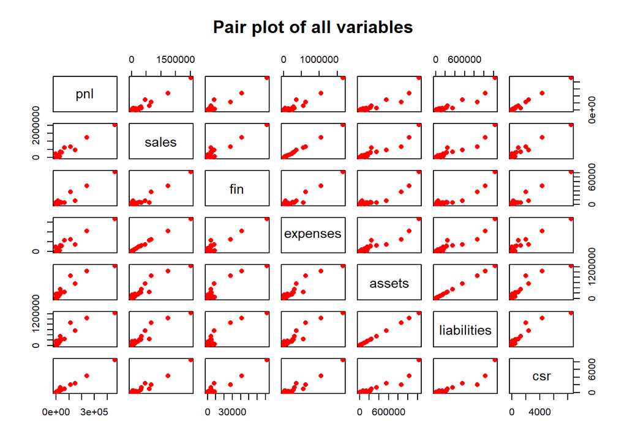

```r
pairs(mydata[c(
  "pnl", "sales", "fin", "expenses", "assets", "liabilities", "csr"
)],
col = "red",
pch = 16,
labels = c(
  "pnl", "sales", "fin", "expenses", "assets", "liabilities", "csr"
),
main = "Pair plot of all variables"
)
```

# 1. Making the linear regression model…

A linear regression model is made using csr expenditure as the dependent variable, and profit, sales, income from financial services, expenses, assets and liabilities as the independent variables. We are going to test how well the csr expenditure can be predicted based on these factors…

```r
lmmodel <- lm(csr ~ pnl+sales+fin+expenses+assets+liabilities, data = mydata)
summary(lmmodel)
```

```
##
## Call:
## lm(formula = csr ~ pnl + sales + fin + expenses + assets + liabilities,
##     data = mydata)
##
## Residuals:
##     Min      1Q  Median      3Q     Max
## -219.48   -3.07    0.54    3.32  625.20
##
## Coefficients: (1 not defined because of singularities)
##               Estimate Std. Error t value Pr(>|t|)
## (Intercept) -1.0108084  2.9386589  -0.344    0.731
## pnl          0.0007501  0.0016144   0.465    0.643
## sales        0.0184938  0.0019777   9.351  < 2e-16 ***
## fin          0.0160986  0.0024116   6.675 1.25e-10 ***
## expenses    -0.0188845  0.0020641  -9.149  < 2e-16 ***
## assets       0.0006632  0.0001148   5.780 1.93e-08 ***
## liabilities         NA         NA      NA       NA
## ---
## Signif. codes:  0 '***' 0.001 '**' 0.01 '*' 0.05 '.' 0.1 ' ' 1
##
## Residual standard error: 48.07 on 291 degrees of freedom
## Multiple R-squared:  0.9934, Adjusted R-squared:  0.9933
## F-statistic:  8815 on 5 and 291 DF,  p-value: < 2.2e-16
```

### Analysis

As we can see, R-squared = 0.9934 and Adjusted R-squared = 0.9933. It implies that our model explains the variation upto 99%!

### But

The model is not free of errors. These need to be tested out

# 2. Test for heteroskedasticity

##### Note:

Heteroskedasticity occurs when the variance of residuals is not a constant value, but it varies as a function of the variables x1, x2,….xk

H0 : all coefficients are 0 Ha : coefficients are not 0

so, if p-value < 0.05, then it implies that null hypothesis is to be rejected and there EXISTS heteroskedasticity in our model.

#### Collecting the variables and fitted values.

```r
my_residuals <- resid(lmmodel)
fitted_val <- fitted(lmmodel)

residuals_sq <- my_residuals^2
```

#### Plotting the residuals against each variable.

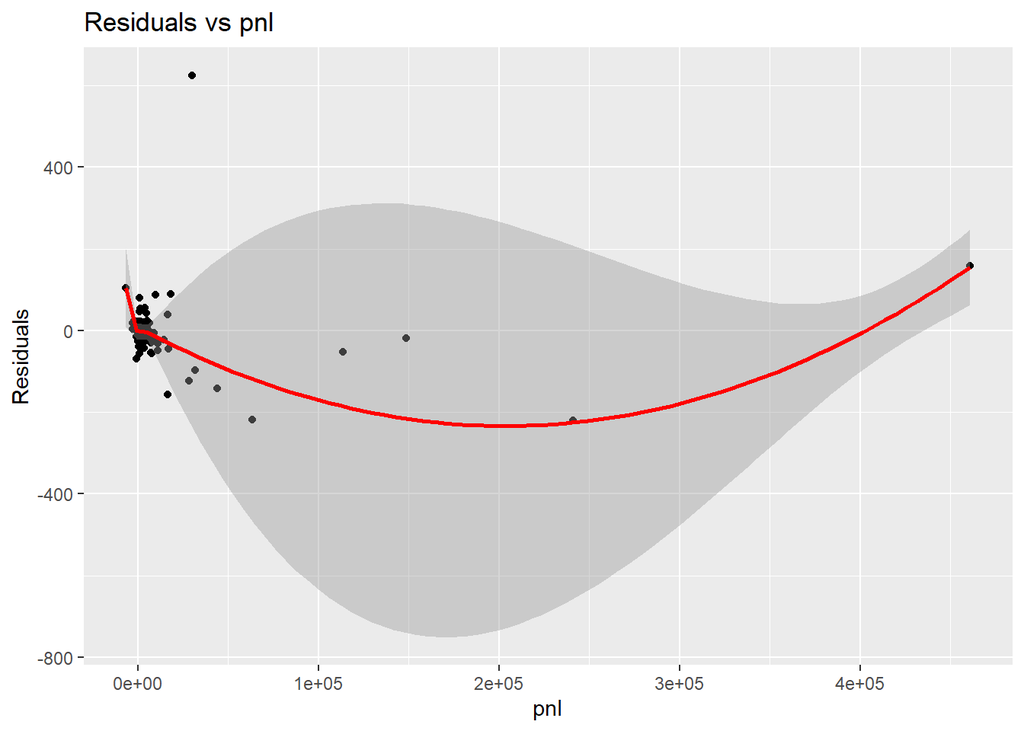

```r
plot_residuals <- function(variable) {
  ggplot(mydata, aes_string(x = variable, y = my_residuals)) +
    geom_point() +
    geom_smooth(method = "loess", col = "red") +
    labs(title = paste("Residuals vs", variable), x = variable, y = "Residuals")
}

# Plot residuals against each predictor
plot_residuals("pnl")
```

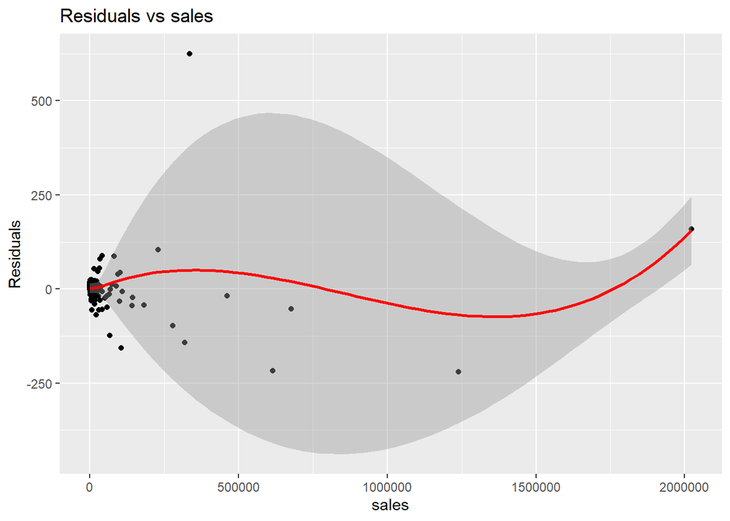

```r
plot_residuals("sales")
```

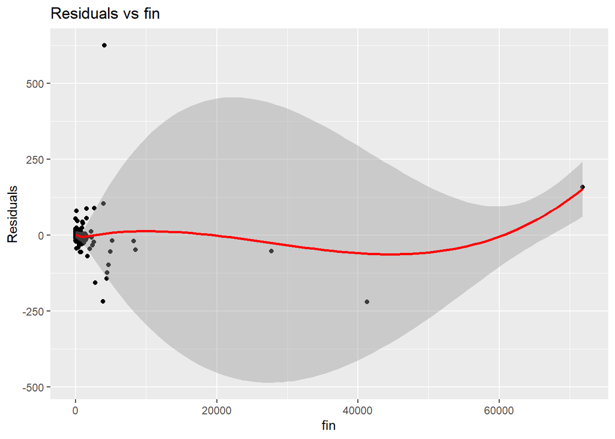

```r
plot_residuals("fin")
```

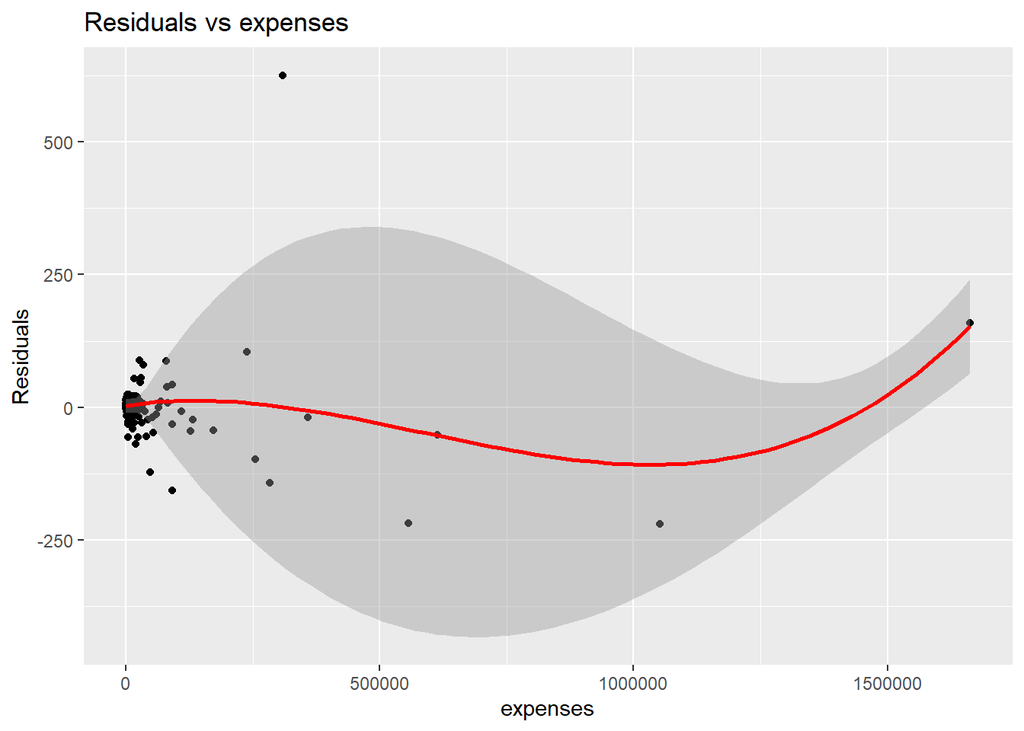

```r
plot_residuals("expenses")
```

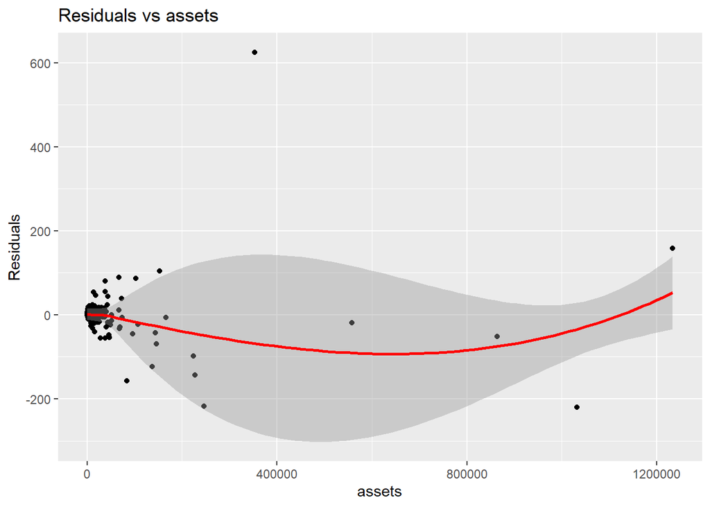

```r
plot_residuals("assets")
```

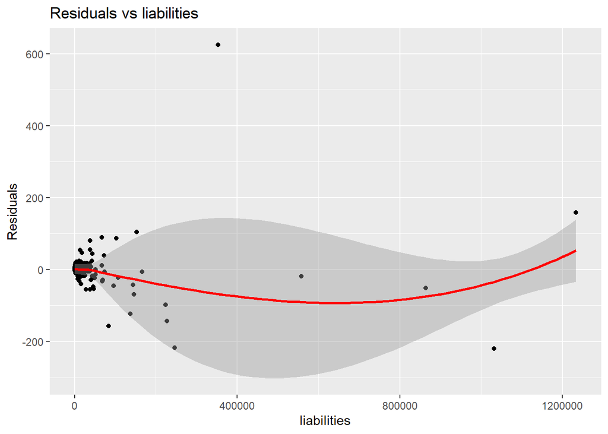

```r
plot_residuals("liabilities")
```

There seems to be significant heteroskedasticity present.

There are several tests that can be done on a regression model to test for heteroskedasticity…this project conducts 4 of them, namely the Breusch-Pagan Test, White’s Test, Park’s Test and Goldfeld-Quant Test.

```r
printresult <- function(pvalue, testname, errorname) {
  cat("P value is = ", pvalue, "\n")

  if (pvalue >= 0.05) {
    cat("Result: The null hypothesis of ", testname, " cannot be rejected. There exists NO significant ", errorname, "\n")
  } else {
    cat("Result: The null hypothesis of ", testname, " is rejected!! There EXISTS", errorname, "\n")
  }
}
```

## 1) Breusch-Pagan Test

```r
auxi_model_bp <- lm(residuals_sq ~ pnl+sales+fin+expenses+assets+liabilities, data = mydata)


summary_auxi_bp <- summary(auxi_model_bp)

summary_auxi_bp
```

```
##
## Call:
## lm(formula = residuals_sq ~ pnl + sales + fin + expenses + assets +
##     liabilities, data = mydata)
##
## Residuals:
##    Min     1Q Median     3Q    Max
## -64020   -854    815   1261 305746
##
## Coefficients: (1 not defined because of singularities)
##               Estimate Std. Error t value Pr(>|t|)
## (Intercept) -1.161e+03  1.219e+03  -0.953 0.341634
## pnl         -2.870e+00  6.698e-01  -4.286 2.48e-05 ***
## sales        3.049e+00  8.205e-01   3.717 0.000242 ***
## fin         -2.505e+00  1.000e+00  -2.503 0.012845 *
## expenses    -2.990e+00  8.563e-01  -3.491 0.000555 ***
## assets       2.437e-01  4.761e-02   5.119 5.59e-07 ***
## liabilities         NA         NA      NA       NA
## ---
## Signif. codes:  0 '***' 0.001 '**' 0.01 '*' 0.05 '.' 0.1 ' ' 1
##
## Residual standard error: 19940 on 291 degrees of freedom
## Multiple R-squared:  0.2686, Adjusted R-squared:  0.256
## F-statistic: 21.37 on 5 and 291 DF,  p-value: < 2.2e-16
```

```r
r_squared_bp <- summary_auxi_bp$r.squared
n <- nrow(mydata)

n
```

```
## [1] 297
```

```r
bp_statistic <- n * r_squared_bp

df_manual_bp <- length(coefficients(lmmodel)) - 1  # Number of predictors

p_value_manual <- pchisq(bp_statistic, df_manual_bp, lower.tail = FALSE)

cat("R-squared:", r_squared_bp, "\n")
```

```
## R-squared: 0.2685663
```

```r
cat("BP Statistic:", bp_statistic, "\n")
```

```
## BP Statistic: 79.76419
```

```r
cat("Degrees of Freedom:", df_manual_bp, "\n")
```

```
## Degrees of Freedom: 6
```

```r
cat("p-value:", p_value_manual, "\n")
```

```
## p-value: 3.996888e-15
```

```r
printresult(p_value_manual, "Homoskedasticity", "Heteroskedasticity")
```

```
## P value is =  3.996888e-15
## Result: The null hypothesis of  Homoskedasticity  is rejected!! There EXISTS Heteroskedasticity
```

## 2)White’s test

```r
# we already have values of fitted variables and the residual squares...
fitted_sq <- fitted_val^2

auxi_model_w <- lm(residuals_sq ~ fitted_val + fitted_sq, data = mydata)

r_squared_w <- summary(auxi_model_w)$r.squared
bp_statistic_w <- n* r_squared_w

df_manual_w <- 2  # because we have fit and fit_sq
p_value <- 1 - pchisq(bp_statistic_w, df_manual_w)

#cat("p-value:", p_value, "\n")

printresult(p_value, "Homoskedasticity", "Heteroskedasticity")
```

```
## P value is =  3.799327e-06
## Result: The null hypothesis of  Homoskedasticity  is rejected!! There EXISTS Heteroskedasticity
```

## 3) Park’s test

```r
log_residuals_sq <- log(residuals_sq)

#making the auxiliary model
auxi_model_park <- lm(log_residuals_sq ~ log(pnl) + log(sales) + log(fin) + log(expenses) + log(assets) + log(liabilities), data = mydata)
summary_auxi_park <- summary(auxi_model_park)

summary_auxi_park
```

```
##
## Call:
## lm(formula = log_residuals_sq ~ log(pnl) + log(sales) + log(fin) +
##     log(expenses) + log(assets) + log(liabilities), data = mydata)
##
## Residuals:
##      Min       1Q   Median       3Q      Max
## -15.7447  -1.3792   0.4355   1.7865   6.6186
##
## Coefficients: (1 not defined because of singularities)
##                  Estimate Std. Error t value Pr(>|t|)
## (Intercept)      -10.6016     1.2575  -8.430 1.96e-15 ***
## log(pnl)          -0.3374     0.1969  -1.714 0.087678 .
## log(sales)        -0.4788     1.4183  -0.338 0.735958
## log(fin)           0.2517     0.1491   1.688 0.092541 .
## log(expenses)      0.9003     1.4168   0.635 0.525668
## log(assets)        1.1951     0.3312   3.608 0.000366 ***
## log(liabilities)       NA         NA      NA       NA
## ---
## Signif. codes:  0 '***' 0.001 '**' 0.01 '*' 0.05 '.' 0.1 ' ' 1
##
## Residual standard error: 2.854 on 275 degrees of freedom
##   (16 observations deleted due to missingness)
## Multiple R-squared:  0.4345, Adjusted R-squared:  0.4242
## F-statistic: 42.25 on 5 and 275 DF,  p-value: < 2.2e-16
```

```r
r_squared_park <- summary_auxi_park$r.squared

#finding the test stat
n <- nrow(mydata)
p_stat <- n * r_squared_park

#finding the df

df_park <- length(coefficients(auxi_model_park)) - 1  # Excluding the intercept

#The chi square test is used
p_value_park <- pchisq(p_stat, df_park, lower.tail = FALSE)

cat("R Squared: ", r_squared_park, "\n")
```

```
## R Squared:  0.4344629
```

```r
cat("Degrees of Freedom:", df_park, "\n")
```

```
## Degrees of Freedom: 6
```

```r
cat("BP Statistic:", p_stat, "\n")
```

```
## BP Statistic: 129.0355
```

```r
#cat("p-value:", p_value_park, "\n")

printresult(p_value_park, "Homoskedasticity", "Heteroskedasticity")
```

```
## P value is =  2.051598e-25
## Result: The null hypothesis of  Homoskedasticity  is rejected!! There EXISTS Heteroskedasticity
```

## 4) Goldfeld Quant Test

```r
sorted_data <- mydata[order(mydata$sales), ]

n <- nrow(sorted_data)
c <- floor(0.20 * n) #keeping c as 20% of the data....c will then be omitted!

group_size <- (n-c)/2

group1 <- sorted_data[1:group_size, ]
group2 <- sorted_data[(group_size+c+1): n, ]
```

now regression is run for both groups…

```r
model1 <- lm(csr ~ pnl+sales+fin+expenses+assets+liabilities, data = group1)

rss1 <- sum(resid(model1)^2)

model2 <- lm(csr ~ pnl+sales+fin+expenses+assets+liabilities, data = group2)

rss2 <- sum(resid(model2)^2)


gq_statistic <- rss2/rss1
```

- df1 is associated with the numerator of the F-statistic and should correspond to the group with the larger RSS.
- df2 is associated with the denominator of the F-statistic and should correspond to the group with the smaller RSS.

```r
df1_gq <- nrow(group2) - length(coefficients(model2))
df2_gq <- nrow(group1) - length(coefficients(model1))


p_value_gq <- pf(gq_statistic, df1_gq, df2_gq, lower.tail = FALSE)

cat("Goldfeld-Quandt Test Statistic:", gq_statistic, "\n")
```

```
## Goldfeld-Quandt Test Statistic: 468.572
```

```r
cat("Degrees of Freedom:", df1_gq, df2_gq, "\n")
```

```
## Degrees of Freedom: 112 112
```

```r
#cat("p-value:", p_value_gq, "\n")

printresult(p_value_gq, "Homoskedasticity", "Heteroskedasticity")
```

```
## P value is =  4.220262e-118
## Result: The null hypothesis of  Homoskedasticity  is rejected!! There EXISTS Heteroskedasticity
```

# 3) Test for Multicollinearity

```r
#vif(lmmodel) this is creating error....one variable is perfectly collinear with another.
alias(lmmodel)
```

```
## Model :
## csr ~ pnl + sales + fin + expenses + assets + liabilities
##
## Complete :
##             (Intercept) pnl sales fin expenses assets
## liabilities 0           0   0     0   0        1
```

What can be seen here is that there is a perfect multicollinearity between the “assets” and “liabilities” variables. In other words, “assets” can be expressed as a linear combination of “liabilities” or vice versa.

This situation makes it impossible to estimate the coefficients for these variables separately. So, we remove one of the variables from the model, i.e. liabilities, to avoid multicollinearity. Checking the VIFS now…

```r
lm_updated <- lm(csr ~ pnl + sales + fin + expenses + assets, data = mydata)
vif(lm_updated)
```

```
##         pnl       sales         fin    expenses      assets
##   348.25985 11707.02788    19.57447  9055.12813    22.28301
```

```r
cor_matrix <- cor(mydata[c("pnl", "sales", "fin", "expenses", "assets")])
cor_matrix
```

```
##                pnl     sales       fin  expenses    assets
## pnl      1.0000000 0.9697174 0.9670472 0.9579365 0.9246829
## sales    0.9697174 1.0000000 0.9572231 0.9989123 0.9533597
## fin      0.9670472 0.9572231 1.0000000 0.9505169 0.9267040
## expenses 0.9579365 0.9989123 0.9505169 1.0000000 0.9556454
## assets   0.9246829 0.9533597 0.9267040 0.9556454 1.0000000
```

As the vifs have very high value, there is more than sufficient proof to say that significant multicollinearity does exist! This is treated later in the project using the concept of Principal Component Analysis.

# 4) Test for Autocorrelation

## 1) Durbin Watson Test

```r
dwtest(formula = lmmodel, alternative = "two.sided")
```

```
##
##  Durbin-Watson test
##
## data:  lmmodel
## DW = 2.0615, p-value = 0.4772
## alternative hypothesis: true autocorrelation is not 0
```

As p-value is > 0.05, there exists NO SIGNIFICANT AUTOCORRELATION.

## 2) Breusch Godfrey Test

We can check again using the BG Test.

```r
bg_test_result_2 <- bgtest(lmmodel, order = 2)
print(bg_test_result_2)
```

```
##
##  Breusch-Godfrey test for serial correlation of order up to 2
##
## data:  lmmodel
## LM test = 0.7417, df = 2, p-value = 0.6901
```

As p-value is > 0.05, there exists NO SIGNIFICANT AUTOCORRELATION.

# 5) Remedy for Mutlicollinearity

### Principal Component Analysis (PCA)

PCA is a technique used for dimension reduction. That is, it reduces the number of variables while retaining all important information.

```r
ind_vars <- mydata[, c("pnl", "sales", "expenses", "fin", "assets", "liabilities")]

pca_result <- prcomp(ind_vars, scale = TRUE)

selected_pcs <- pca_result $ x[, 1:3] #we are only going to consider the three most significant PCs

new_lmmodel <- lm(csr ~ selected_pcs, data = mydata)

summary(new_lmmodel)
```

```
##
## Call:
## lm(formula = csr ~ selected_pcs, data = mydata)
##
## Residuals:
##     Min      1Q  Median      3Q     Max
## -495.02   -1.05    4.38    7.78  722.79
##
## Coefficients:
##                 Estimate Std. Error t value Pr(>|t|)
## (Intercept)       99.607      4.677  21.297  < 2e-16 ***
## selected_pcsPC1  239.322      1.950 122.753  < 2e-16 ***
## selected_pcsPC2  255.327     12.729  20.059  < 2e-16 ***
## selected_pcsPC3  -72.635     19.185  -3.786 0.000186 ***
## ---
## Signif. codes:  0 '***' 0.001 '**' 0.01 '*' 0.05 '.' 0.1 ' ' 1
##
## Residual standard error: 80.6 on 293 degrees of freedom
## Multiple R-squared:  0.9814, Adjusted R-squared:  0.9812
## F-statistic:  5162 on 3 and 293 DF,  p-value: < 2.2e-16
```

Now a scree plot must be created. For that a new dataframe is created containing the percentage of total variance contributed by each principal component, and of course the names of the PCs.

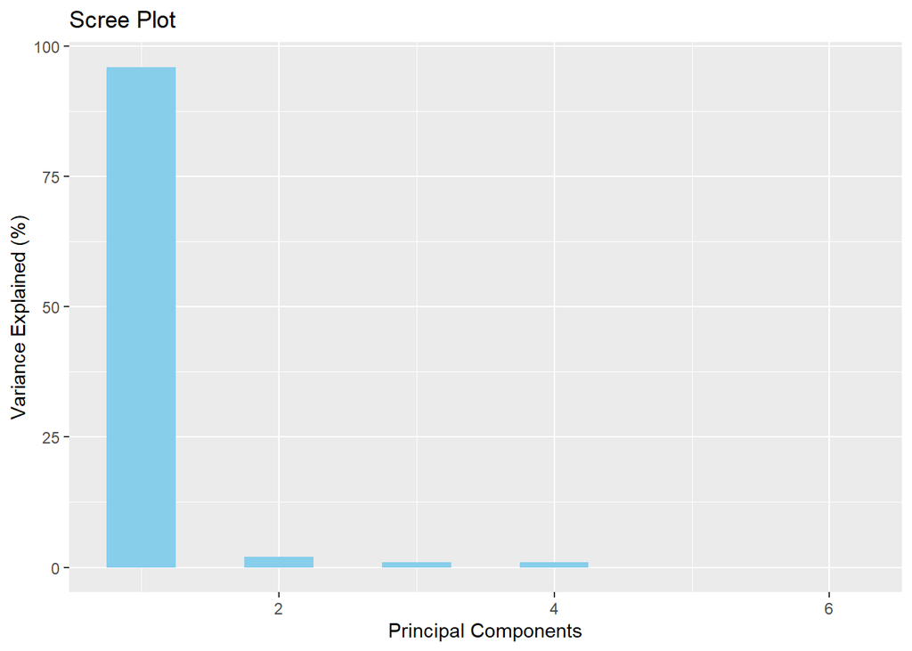

```r
pca_variance <- (pca_result $sdev)^2

pca_var_perc <- round( pca_variance/ sum(pca_variance)  * 100)

scree_data <- data.frame(
  PC = 1:length(pca_var_perc),
  variance_pc = pca_var_perc
)

View(scree_data)

ggplot(data = scree_data, aes(x = PC, y = variance_pc)) +
  geom_bar(stat = "identity", fill = "skyblue", width = 0.5) +
  labs(title = "Scree Plot", x = "Principal Components", y = "Variance Explained (%)")
```

## Impact of PCA on this model…

What has occurred here is that PCA was used to transform the 6 financial variables into 3 new variables called the Principal Components (PCs). These PCs are inherently UNCORRELATED to each other (by definition). Therefore, multicollinearity is removed.

These PCs are linear combinations of the original variables and are designed to capture the most important patterns in the data.

Each PC is a weighted average of the original variables.

So, the dependent variable is strongly associated with not the original variable, but, a combined effect of the original dependent variables as per the loadings of the PCs.

The coefficients in the linear combination can be found by accessing the ‘rotation’ of the pca_result, which is nothing but the Loadings.

```r
print(pca_result $ rotation)
```

```
##                   PC1         PC2        PC3         PC4          PC5
## pnl         0.4061005  0.45757028 -0.1561822 -0.76537878  0.124556274
## sales       0.4124094  0.14945632  0.4951418  0.08589017 -0.745009233
## expenses    0.4114328  0.07021516  0.5785952  0.24881503  0.655066090
## fin         0.4049580  0.41280106 -0.5760156  0.57768923 -0.009244624
## assets      0.4072670 -0.54449856 -0.1787112 -0.07478114 -0.011178824
## liabilities 0.4072670 -0.54449856 -0.1787112 -0.07478114 -0.011178824
##                       PC6
## pnl         -2.906798e-15
## sales        1.779824e-14
## expenses    -1.602729e-14
## fin          8.252674e-17
## assets       7.071068e-01
## liabilities -7.071068e-01
```

#### PC1=0.4061⋅pnl+0.4124⋅sales+0.4114⋅expenses+0.4050⋅fin+0.4073⋅assets+0.4073⋅liabilities

#### PC2=0.4576⋅pnl+0.1495⋅sales+0.0702⋅expenses+0.4128⋅fin−0.5445⋅assets−0.5445⋅liabilities

#### PC3=−0.1562⋅pnl+0.4951⋅sales+0.5786⋅expenses−0.5760⋅fin−0.1787⋅assets−0.1787⋅liabilities

Is this new and improved model free of autocorrelation and heteroskedasticity?

# 6) Test for Autocorrelation on the improved model…

```r
dwtest(formula = new_lmmodel, alternative = "two.sided")
```

```
##
##  Durbin-Watson test
##
## data:  new_lmmodel
## DW = 1.9535, p-value = 0.6889
## alternative hypothesis: true autocorrelation is not 0
```

As p-value is > 0.05, there exists NO SIGNIFICANT AUTOCORRELATION.

# 7) Test for Heteroskedasticity on the improved model…

Let’s just go with Breusch Pagan test for this.

```r
##bptest(new_lmmodel, ~ selected_pcs, data = mydata, studentize = TRUE)

residuals_sq <- (resid(new_lmmodel))^2

auxi_model_bp <- lm(residuals_sq ~ selected_pcs, data = mydata)


summary_auxi_bp <- summary(auxi_model_bp)

summary_auxi_bp
```

```
##
## Call:
## lm(formula = residuals_sq ~ selected_pcs, data = mydata)
##
## Residuals:
##     Min      1Q  Median      3Q     Max
## -189806   -2614    1364    2563  339162
##
## Coefficients:
##                 Estimate Std. Error t value Pr(>|t|)
## (Intercept)         6409       1881   3.408 0.000746 ***
## selected_pcsPC1     7303        784   9.316  < 2e-16 ***
## selected_pcsPC2   -65661       5118 -12.828  < 2e-16 ***
## selected_pcsPC3     6025       7714   0.781 0.435454
## ---
## Signif. codes:  0 '***' 0.001 '**' 0.01 '*' 0.05 '.' 0.1 ' ' 1
##
## Residual standard error: 32410 on 293 degrees of freedom
## Multiple R-squared:  0.4623, Adjusted R-squared:  0.4568
## F-statistic: 83.99 on 3 and 293 DF,  p-value: < 2.2e-16
```

```r
r_squared_bp <- summary_auxi_bp$r.squared
n <- nrow(mydata)

n
```

```
## [1] 297
```

```r
bp_statistic <- n * r_squared_bp

df_manual_bp <- length(coefficients(new_lmmodel)) - 1  # Number of predictors

p_value_manual <- pchisq(bp_statistic, df_manual_bp, lower.tail = FALSE)

cat("R-squared:", r_squared_bp, "\n")
```

```
## R-squared: 0.4623439
```

```r
cat("BP Statistic:", bp_statistic, "\n")
```

```
## BP Statistic: 137.3161
```

```r
cat("Degrees of Freedom:", df_manual_bp, "\n")
```

```
## Degrees of Freedom: 3
```

```r
#cat("p-value:", p_value_manual, "\n")

printresult(p_value_manual, "Homoskedasticity", "Heteroskedasticity")
```

```
## P value is =  1.432545e-29
## Result: The null hypothesis of  Homoskedasticity  is rejected!! There EXISTS Heteroskedasticity
```

# 8) Remedy for heteroskedasticity

### Model Transformation

Now, using model transformation to combat heteroskedasticity, the log of dependent variable csr is taken. Note: since there may be a possibility of negative values, a small constant is added to csr to shift the values and avoid the error of negative log.

```r
mydata$log_csr <- log(mydata$csr + 1)  # Adding a small constant (e.g., 1) to avoid non-positive values
transformed_model <- lm(log_csr ~ selected_pcs, data = mydata)
summary(transformed_model)
```

```
##
## Call:
## lm(formula = log_csr ~ selected_pcs, data = mydata)
##
## Residuals:
##     Min      1Q  Median      3Q     Max
## -4.5537 -1.0497  0.0415  0.8746  3.6687
##
## Coefficients:
##                 Estimate Std. Error t value Pr(>|t|)
## (Intercept)      2.61270    0.07261  35.984  < 2e-16 ***
## selected_pcsPC1  0.35708    0.03027  11.798  < 2e-16 ***
## selected_pcsPC2 -1.28536    0.19761  -6.505 3.36e-10 ***
## selected_pcsPC3  0.79799    0.29783   2.679  0.00779 **
## ---
## Signif. codes:  0 '***' 0.001 '**' 0.01 '*' 0.05 '.' 0.1 ' ' 1
##
## Residual standard error: 1.251 on 293 degrees of freedom
## Multiple R-squared:  0.3917, Adjusted R-squared:  0.3855
## F-statistic: 62.89 on 3 and 293 DF,  p-value: < 2.2e-16
```

Checking for heteroskedasticity again….

```r
#Check for heteroskedasticity again
#bptest(transformed_model, ~ selected_pcs, data = mydata, studentize = TRUE)

residuals_sq <- (resid(transformed_model))^2

auxi_model_bp <- lm(residuals_sq ~ selected_pcs, data = mydata)


summary_auxi_bp <- summary(auxi_model_bp)

summary_auxi_bp
```

```
##
## Call:
## lm(formula = residuals_sq ~ selected_pcs, data = mydata)
##
## Residuals:
##     Min      1Q  Median      3Q     Max
## -4.0794 -1.2250 -0.5471  0.7078 19.0776
##
## Coefficients:
##                 Estimate Std. Error t value Pr(>|t|)
## (Intercept)      1.54462    0.11751  13.145  < 2e-16 ***
## selected_pcsPC1  0.11594    0.04898   2.367 0.018584 *
## selected_pcsPC2 -0.61306    0.31981  -1.917 0.056218 .
## selected_pcsPC3 -1.69115    0.48201  -3.509 0.000521 ***
## ---
## Signif. codes:  0 '***' 0.001 '**' 0.01 '*' 0.05 '.' 0.1 ' ' 1
##
## Residual standard error: 2.025 on 293 degrees of freedom
## Multiple R-squared:  0.06862,    Adjusted R-squared:  0.05908
## F-statistic: 7.196 on 3 and 293 DF,  p-value: 0.0001123
```

```r
r_squared_bp <- summary_auxi_bp$r.squared
n <- nrow(mydata)

n
```

```
## [1] 297
```

```r
bp_statistic <- n * r_squared_bp

df_manual_bp <- length(coefficients(transformed_model)) - 1  # Number of predictors

p_value_manual <- pchisq(bp_statistic, df_manual_bp, lower.tail = FALSE)

cat("R-squared:", r_squared_bp, "\n")
```

```
## R-squared: 0.06861984
```

```r
cat("BP Statistic:", bp_statistic, "\n")
```

```
## BP Statistic: 20.38009
```

```r
cat("Degrees of Freedom:", df_manual_bp, "\n")
```

```
## Degrees of Freedom: 3
```

```r
#cat("p-value:", p_value_manual, "\n")

printresult(p_value_manual, "Homoskedasticity", "Heteroskedasticity")
```

```
## P value is =  0.0001415753
## Result: The null hypothesis of  Homoskedasticity  is rejected!! There EXISTS Heteroskedasticity
```

While heteroskedasticity has not completely been removed, it has clearly been reduced judging from the p-value.

# 9) Final Interpretation

Let’s take a look at the summary of transformed_model once more….

```r
summary(transformed_model)
```

```
##
## Call:
## lm(formula = log_csr ~ selected_pcs, data = mydata)
##
## Residuals:
##     Min      1Q  Median      3Q     Max
## -4.5537 -1.0497  0.0415  0.8746  3.6687
##
## Coefficients:
##                 Estimate Std. Error t value Pr(>|t|)
## (Intercept)      2.61270    0.07261  35.984  < 2e-16 ***
## selected_pcsPC1  0.35708    0.03027  11.798  < 2e-16 ***
## selected_pcsPC2 -1.28536    0.19761  -6.505 3.36e-10 ***
## selected_pcsPC3  0.79799    0.29783   2.679  0.00779 **
## ---
## Signif. codes:  0 '***' 0.001 '**' 0.01 '*' 0.05 '.' 0.1 ' ' 1
##
## Residual standard error: 1.251 on 293 degrees of freedom
## Multiple R-squared:  0.3917, Adjusted R-squared:  0.3855
## F-statistic: 62.89 on 3 and 293 DF,  p-value: < 2.2e-16
```

The regression model summary shows some interesting results.

The intercept is at 2.61270, and it’s highly significant (p < 2e-16). PC1 has a positive effect with a coefficient of 0.35708 and is also very significant (p < 2e-16). PC2, on the other hand, has a negative impact with a coefficient of -1.28536 (p = 3.36e-10). PC3 is positively affecting the outcome with a coefficient of 0.79799, and it’s significant as well (p = 0.00779).

Looking at the model fit, the residual standard error is 1.251. The R-squared value is 0.3917, meaning the model explains 39.17% of the variance in the data. The adjusted R-squared is slightly lower at 0.3855, but still solid. The F-statistic is 62.89 with a p-value of less than 2.2e-16, indicating the overall model is highly significant.

#### In summary, the regression model shows that the selected principal components (PC1, PC2, and PC3) significantly predict the log-transformed CSR matrix. PC1 and PC3 have positive effects, while PC2 has a negative effect on the log-transformed CSR values. The model explains a moderate portion of the variance, and the overall fit is statistically significant.